# Chapter 4

```r
library(pacman)
# stat libs
p_load(MASS, ISLR)
# data cleaning
p_load(broom, dplyr, janitor)
# plots
p_load(corrplot, ggplot2)
```

## Q 10

### cleaning column names

```r
weekly = Weekly %>% clean_names()
```

**trend in volume**

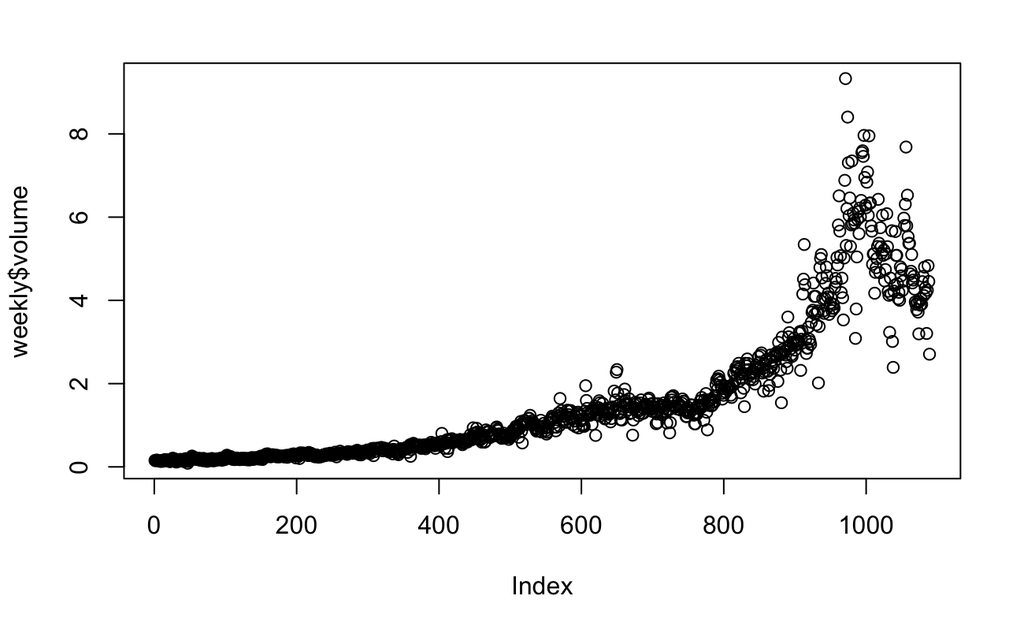

```r
plot(weekly$volume)
```

**examine the structure of the data**

```r
head(weekly)
```

|  | year | lag1 | lag2 | lag3 | lag4 | lag5 | volume | today | direction |
| --- | --- | --- | --- | --- | --- | --- | --- | --- | --- |
| 1 | 1990 | 0.816 | 1.572 | -3.936 | -0.229 | -3.484 | 0.1549760 | -0.270 | Down |
| 2 | 1990 | -0.270 | 0.816 | 1.572 | -3.936 | -0.229 | 0.1485740 | -2.576 | Down |
| 3 | 1990 | -2.576 | -0.270 | 0.816 | 1.572 | -3.936 | 0.1598375 | 3.514 | Up |
| 4 | 1990 | 3.514 | -2.576 | -0.270 | 0.816 | 1.572 | 0.1616300 | 0.712 | Up |
| 5 | 1990 | 0.712 | 3.514 | -2.576 | -0.270 | 0.816 | 0.1537280 | 1.178 | Up |
| 6 | 1990 | 1.178 | 0.712 | 3.514 | -2.576 | -0.270 | 0.1544440 | -1.372 | Down |

```r
str(weekly)
```

```
'data.frame':   1089 obs. of  9 variables:
 $ year     : num  1990 1990 1990 1990 1990 1990 1990 1990 1990 1990 ...
 $ lag1     : num  0.816 -0.27 -2.576 3.514 0.712 ...
 $ lag2     : num  1.572 0.816 -0.27 -2.576 3.514 ...
 $ lag3     : num  -3.936 1.572 0.816 -0.27 -2.576 ...
 $ lag4     : num  -0.229 -3.936 1.572 0.816 -0.27 ...
 $ lag5     : num  -3.484 -0.229 -3.936 1.572 0.816 ...
 $ volume   : num  0.155 0.149 0.16 0.162 0.154 ...
 $ today    : num  -0.27 -2.576 3.514 0.712 1.178 ...
 $ direction: Factor w/ 2 levels "Down","Up": 1 1 2 2 2 1 2 2 2 1 ...
```

```r
summary(weekly)
```

```
      year           lag1               lag2               lag3
 Min.   :1990   Min.   :-18.1950   Min.   :-18.1950   Min.   :-18.1950
 1st Qu.:1995   1st Qu.: -1.1540   1st Qu.: -1.1540   1st Qu.: -1.1580
 Median :2000   Median :  0.2410   Median :  0.2410   Median :  0.2410
 Mean   :2000   Mean   :  0.1506   Mean   :  0.1511   Mean   :  0.1472
 3rd Qu.:2005   3rd Qu.:  1.4050   3rd Qu.:  1.4090   3rd Qu.:  1.4090
 Max.   :2010   Max.   : 12.0260   Max.   : 12.0260   Max.   : 12.0260
      lag4               lag5              volume
 Min.   :-18.1950   Min.   :-18.1950   Min.   :0.08747
 1st Qu.: -1.1580   1st Qu.: -1.1660   1st Qu.:0.33202
 Median :  0.2380   Median :  0.2340   Median :1.00268
 Mean   :  0.1458   Mean   :  0.1399   Mean   :1.57462
 3rd Qu.:  1.4090   3rd Qu.:  1.4050   3rd Qu.:2.05373
 Max.   : 12.0260   Max.   : 12.0260   Max.   :9.32821
     today          direction
 Min.   :-18.1950   Down:484
 1st Qu.: -1.1540   Up  :605
 Median :  0.2410
 Mean   :  0.1499
 3rd Qu.:  1.4050
 Max.   : 12.0260
```

**quickly examine trends among variables**

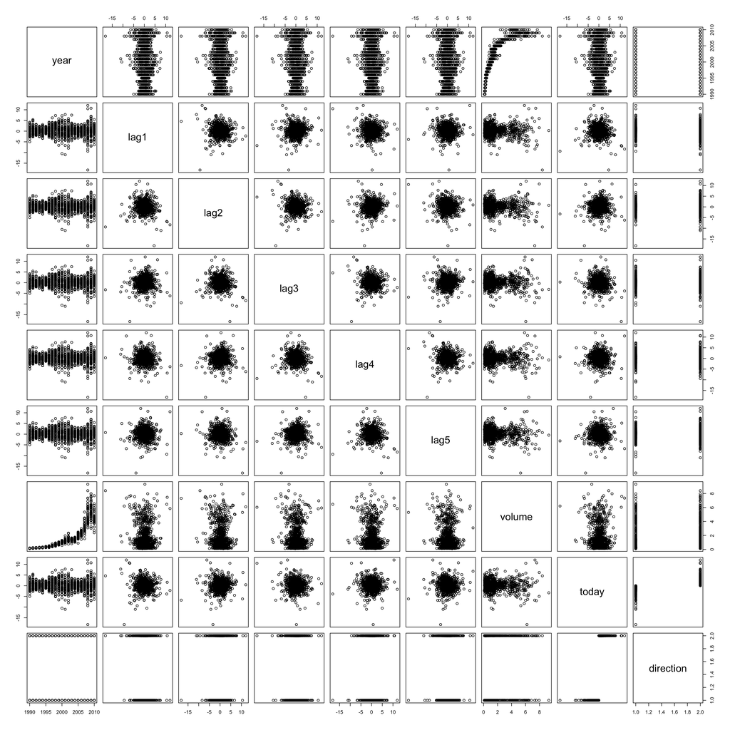

```r
pairs(weekly)
```

```r
cor(weekly[, -9])
```

```
              year         lag1        lag2        lag3         lag4
year    1.00000000 -0.032289274 -0.03339001 -0.03000649 -0.031127923
lag1   -0.03228927  1.000000000 -0.07485305  0.05863568 -0.071273876
lag2   -0.03339001 -0.074853051  1.00000000 -0.07572091  0.058381535
lag3   -0.03000649  0.058635682 -0.07572091  1.00000000 -0.075395865
lag4   -0.03112792 -0.071273876  0.05838153 -0.07539587  1.000000000
lag5   -0.03051910 -0.008183096 -0.07249948  0.06065717 -0.075675027
volume  0.84194162 -0.064951313 -0.08551314 -0.06928771 -0.061074617
today  -0.03245989 -0.075031842  0.05916672 -0.07124364 -0.007825873
               lag5      volume        today
year   -0.030519101  0.84194162 -0.032459894
lag1   -0.008183096 -0.06495131 -0.075031842
lag2   -0.072499482 -0.08551314  0.059166717
lag3    0.060657175 -0.06928771 -0.071243639
lag4   -0.075675027 -0.06107462 -0.007825873
lag5    1.000000000 -0.05851741  0.011012698
volume -0.058517414  1.00000000 -0.033077783
today   0.011012698 -0.03307778  1.000000000
```

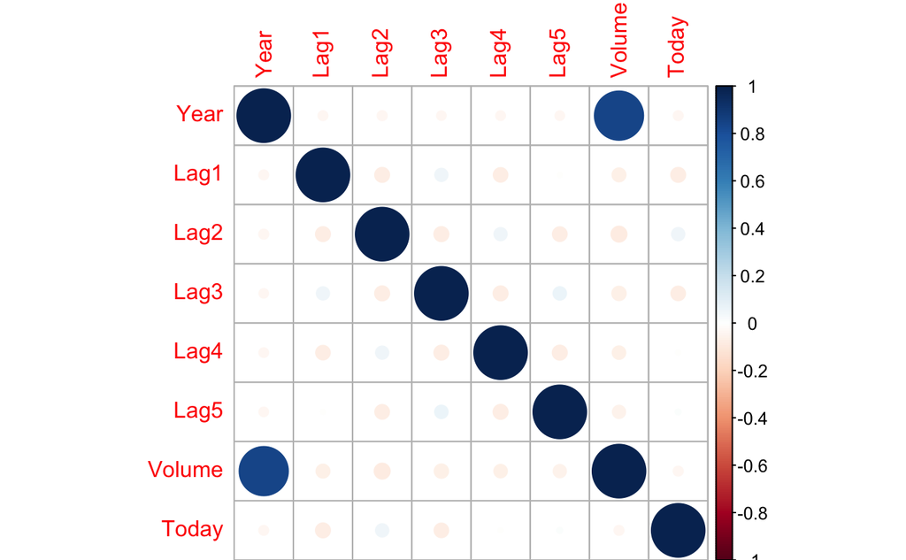

```r
corrplot(cor(Weekly[, -9]))
```

Let us fit a logistic model to begin with:

### b

```r
glm_fit_a = glm(direction ~ lag1 + lag2 + lag3 + lag4 + lag5 + volume,
              data = weekly, family = "binomial")
tidy(glm_fit_a)
```

| term | estimate | std.error | statistic | p.value |
| --- | --- | --- | --- | --- |
| (Intercept) | 0.26686414 | 0.08592961 | 3.1056134 | 0.001898848 |
| lag1 | -0.04126894 | 0.02641026 | -1.5626099 | 0.118144368 |
| lag2 | 0.05844168 | 0.02686499 | 2.1753839 | 0.029601361 |
| lag3 | -0.01606114 | 0.02666299 | -0.6023760 | 0.546923890 |
| lag4 | -0.02779021 | 0.02646332 | -1.0501409 | 0.293653342 |
| lag5 | -0.01447206 | 0.02638478 | -0.5485006 | 0.583348244 |
| volume | -0.02274153 | 0.03689812 | -0.6163330 | 0.537674762 |

```r
summary(glm_fit_a)
```

```
Call:
glm(formula = direction ~ lag1 + lag2 + lag3 + lag4 + lag5 +
    volume, family = "binomial", data = weekly)

Deviance Residuals:
    Min       1Q   Median       3Q      Max
-1.6949  -1.2565   0.9913   1.0849   1.4579

Coefficients:
            Estimate Std. Error z value Pr(>|z|)
(Intercept)  0.26686    0.08593   3.106   0.0019 **
lag1        -0.04127    0.02641  -1.563   0.1181
lag2         0.05844    0.02686   2.175   0.0296 *
lag3        -0.01606    0.02666  -0.602   0.5469
lag4        -0.02779    0.02646  -1.050   0.2937
lag5        -0.01447    0.02638  -0.549   0.5833
volume      -0.02274    0.03690  -0.616   0.5377
---
Signif. codes:  0 ‘***’ 0.001 ‘**’ 0.01 ‘*’ 0.05 ‘.’ 0.1 ‘ ’ 1

(Dispersion parameter for binomial family taken to be 1)

    Null deviance: 1496.2  on 1088  degrees of freedom
Residual deviance: 1486.4  on 1082  degrees of freedom
AIC: 1500.4

Number of Fisher Scoring iterations: 4
```

```r
# no intercept
glm_fit_b = glm(direction ~ 0 + lag1 + lag2 + lag3 +
                 lag4 + lag5 + volume, data = weekly,
               family = binomial)
summary(glm_fit_b)
```

```
Call:
glm(formula = direction ~ 0 + lag1 + lag2 + lag3 + lag4 + lag5 +
    volume, family = binomial, data = weekly)

Deviance Residuals:
   Min      1Q  Median      3Q     Max
-1.726  -1.191   1.033   1.148   1.553

Coefficients:
        Estimate Std. Error z value Pr(>|z|)
lag1   -0.032730   0.026177  -1.250   0.2112
lag2    0.068196   0.026685   2.556   0.0106 *
lag3   -0.008099   0.026447  -0.306   0.7594
lag4   -0.019420   0.026231  -0.740   0.4591
lag5   -0.006856   0.026230  -0.261   0.7938
volume  0.056925   0.026792   2.125   0.0336 *
---
Signif. codes:  0 ‘***’ 0.001 ‘**’ 0.01 ‘*’ 0.05 ‘.’ 0.1 ‘ ’ 1

(Dispersion parameter for binomial family taken to be 1)

    Null deviance: 1509.7  on 1089  degrees of freedom
Residual deviance: 1496.1  on 1083  degrees of freedom
AIC: 1508.1

Number of Fisher Scoring iterations: 4
```

```r
# changing the sequence of variables
glm_fit_c = glm(direction ~ lag2 + lag3 +
                 lag4 + lag5 + volume + lag1,
                data = weekly,
               family = binomial)
summary(glm_fit_c)
```

```
Call:
glm(formula = direction ~ lag2 + lag3 + lag4 + lag5 + volume +
    lag1, family = binomial, data = weekly)

Deviance Residuals:
    Min       1Q   Median       3Q      Max
-1.6949  -1.2565   0.9913   1.0849   1.4579

Coefficients:
            Estimate Std. Error z value Pr(>|z|)
(Intercept)  0.26686    0.08593   3.106   0.0019 **
lag2         0.05844    0.02686   2.175   0.0296 *
lag3        -0.01606    0.02666  -0.602   0.5469
lag4        -0.02779    0.02646  -1.050   0.2937
lag5        -0.01447    0.02638  -0.549   0.5833
volume      -0.02274    0.03690  -0.616   0.5377
lag1        -0.04127    0.02641  -1.563   0.1181
---
Signif. codes:  0 ‘***’ 0.001 ‘**’ 0.01 ‘*’ 0.05 ‘.’ 0.1 ‘ ’ 1

(Dispersion parameter for binomial family taken to be 1)

    Null deviance: 1496.2  on 1088  degrees of freedom
Residual deviance: 1486.4  on 1082  degrees of freedom
AIC: 1500.4

Number of Fisher Scoring iterations: 4
```

**number of weeks when marker was up/down**

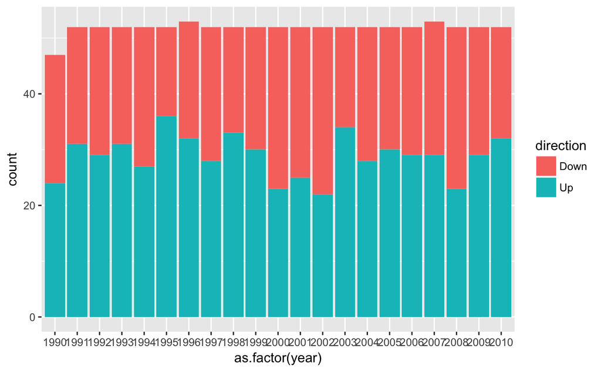

```r
ggplot(weekly, aes(x = as.factor(year), fill = direction)) +
  geom_bar()
```

```r
# Extract coefficients
tidy(coef(glm_fit))
summary(glm_fit$coefficients) # another way to extract coeff.
```

`type` tell glm to output prob in form of P(Y = 1|X)

response: on the scale of Y default: log-odds (default predictions are of log-odds (probabilities on logit scale)

```r
# Use predict function
glm.probs = predict(glm_fit, type = "response")
# type tell glm to output prob in form of P(Y = 1|X)
tidy(glm.probs[1:10])
Smarket[1:10,]
glm_fit$fitted.values[1:10]

df = data.frame(obs_dir = Smarket[,"Direction"],
                fitted = glm_fit$fitted.values, stringsAsFactors = FALSE)
df
```

```r
ggplot(df, aes(Actual, fitted)) + geom_boxplot() + geom_jitter()
```

```r
df = mutate(df, fitted_dir = ifelse(fitted > 0.5, "Up", "Down"))
```

```r
filter(df, obs_dir == "Down", fitted_dir == "Up")

table(df$obs_dir, df$fitted_dir)
```

```r
(507 + 145)/1250
```

Section LDA

```r
p_load(MASS)

train = (Smarket$Year < 2005)

lda_fit = lda(Direction ~ Lag1 + Lag2, data = Smarket, subset = train)
print(lda_fit)
```

```r
plot(lda_fit)
```

```r
smarket_2005 = Smarket [!train, ]
pred_lda = predict(lda_fit, newdata = smarket_2005)

class_lda = pred_lda$class

table(class_lda, smarket_2005$Direction)

mean(class_lda == smarket_2005$Direction)
```

# ’ KNN

```r
p_load(class)

# X: predictors
train.X = cbind(Smarket$Lag1, Smarket$Lag2)[train ,]
test.X = cbind(Smarket$Lag1, Smarket$Lag2)[!train, ]

# Y: response
train.Direction = Smarket$Direction[train]



for(k in 1:4){
  set.seed(1)
  cat("working with k:", k)
  #           training  test    what is the response
  knn.pred = knn(train.X, test.X, train.Direction, k = )
  table(knn.pred, smarket_2005$Direction)
  mean(knn.pred == smarket_2005$Direction)
}
```

Using LDA with MLR

```r
p_load(mlr)
data(iris)

print(iris)

## Define the task
task = makeClassifTask(id = "tutorial", data = iris, target = "Species")

## Define the learner
lrn = makeLearner("classif.lda")

## Define the resampling strategy
rdesc = makeResampleDesc(method = "CV", stratify = TRUE)

## Do the resampling
r = resample(learner = lrn, task = task, resampling = rdesc, show.info = FALSE)

## Get the mean misclassification error
print(r)
```

```r
library(MASS)
fit.lda <- lda(Weekly$direction ~ lag2,
               data = Weekly,
               subset = train)
fit.lda

pred.lda <- predict(fit.lda, Weekly.20092010)
table(pred.lda$class, direction.20092010)
```

## Q 11.

```r
attach(Auto)
mpg01 <- rep(0, length(mpg))
mpg01[mpg > median(mpg)] <- 1
Auto <- data.frame(Auto, mpg01)
```

```r
cor(Auto[, -9])
pairs(Auto)
```

```r
boxplot(cylinders ~ mpg01, data = Auto, main = "Cylinders vs mpg01")
boxplot(displacement ~ mpg01, data = Auto, main = "Displacement vs mpg01")
boxplot(horsepower ~ mpg01, data = Auto, main = "Horsepower vs mpg01")
boxplot(weight ~ mpg01, data = Auto, main = "Weight vs mpg01")
boxplot(acceleration ~ mpg01, data = Auto, main = "Acceleration vs mpg01")
boxplot(year ~ mpg01, data = Auto, main = "Year vs mpg01")
```

```r
train = (year%%2 == 0)  # if the year is even
test = !train
Auto.train = Auto[train, ]
Auto.test = Auto[test, ]
mpg01.test = mpg01[test]
```

4. Perform LDA on the training data in order to predict “mpg01” using the variables that seemed most associated with “mpg01” in (b). What is the test error of the model obtained ?

```r
p_load(MASS)

# LDA
library(MASS)
lda.fit = lda(mpg01 ~ cylinders + weight + displacement + horsepower,
              data = Auto,
    subset = train)
lda.pred = predict(lda.fit, Auto.test)
mean(lda.pred$class != mpg01.test)
```

```r
# QDA
qda.fit = qda(mpg01 ~ cylinders + weight + displacement + horsepower, data = Auto,
    subset = train)
qda.pred = predict(qda.fit, Auto.test)
mean(qda.pred$class != mpg01.test)
```

6. logistic

```r
# Logistic regression
glm.fit = glm(mpg01 ~ cylinders + weight + displacement + horsepower, data = Auto,
    family = binomial, subset = train)
glm.probs = predict(glm.fit, Auto.test, type = "response")
glm.pred = rep(0, length(glm.probs))
glm.pred[glm.probs > 0.5] = 1
mean(glm.pred != mpg01.test)
```

7. KNN

```r
library(class)
train.X = cbind(cylinders, weight, displacement, horsepower)[train, ]
test.X = cbind(cylinders, weight, displacement, horsepower)[test, ]
train.mpg01 = mpg01[train]
set.seed(1)

# KNN(k=1)
knn.pred = knn(train.X, test.X, train.mpg01, k = 1)
mean(knn.pred != mpg01.test)

# KNN(k=10)
knn.pred = knn(train.X, test.X, train.mpg01, k = 10)
mean(knn.pred != mpg01.test)

# KNN(k=100)
knn.pred = knn(train.X, test.X, train.mpg01, k = 100)
mean(knn.pred != mpg01.test)
```